# ADS502 - Group Assignment - Fetal Classification

### R Libraries

```r
library(reshape2)
library(corrplot)
library(ggplot2)
library(dplyr)
library(caret)
library(tidyverse)
library(arules)
library(e1071)
library(caret)
library(class)
library(kableExtra)
library(C50)
library(partykit)
library(nnet)
library(rpart)
library(rpart.plot)
library(caret)
library(randomForest)
library(ggcorrplot)
options(scipen=999)
```

## Exploratory Data Analysis

In this section, we will explore our data and develop an understanding of the information available to us. Our overall goal is to determine which records in the set may be prone to higher chances of mortality.

### Read data

```r
fetal_df <- read.csv(file = 'fetal_health.csv')
head(fetal_df)
```

```
##   baseline.value accelerations fetal_movement uterine_contractions
## 1            120         0.000              0                0.000
## 2            132         0.006              0                0.006
## 3            133         0.003              0                0.008
## 4            134         0.003              0                0.008
## 5            132         0.007              0                0.008
## 6            134         0.001              0                0.010
##   light_decelerations severe_decelerations prolongued_decelerations
## 1               0.000                    0                    0.000
## 2               0.003                    0                    0.000
## 3               0.003                    0                    0.000
## 4               0.003                    0                    0.000
## 5               0.000                    0                    0.000
## 6               0.009                    0                    0.002
##   abnormal_short_term_variability mean_value_of_short_term_variability
```

[output cut: 41 more lines]

### Missing Values

As we see below, there are no missing values in this dataset. Thus, no action will be taken in this regard.

```r
## Count of missing values for each column.
sapply(fetal_df, function(x) sum(is.na(x)))
```

```
##                                         baseline.value
##                                                      0
##                                          accelerations
##                                                      0
##                                         fetal_movement
##                                                      0
##                                   uterine_contractions
##                                                      0
##                                    light_decelerations
##                                                      0
##                                   severe_decelerations
##                                                      0
##                               prolongued_decelerations
##                                                      0
##                        abnormal_short_term_variability
##                                                      0
##                   mean_value_of_short_term_variability
##                                                      0
## percentage_of_time_with_abnormal_long_term_variability
##                                                      0
##                    mean_value_of_long_term_variability
##                                                      0
##                                        histogram_width
##                                                      0
##                                          histogram_min
##                                                      0
##                                          histogram_max
##                                                      0
##                              histogram_number_of_peaks
##                                                      0
##                             histogram_number_of_zeroes
##                                                      0
##                                         histogram_mode
##                                                      0
##                                         histogram_mean
##                                                      0
##                                       histogram_median
##                                                      0
##                                     histogram_variance
##                                                      0
##                                     histogram_tendency
##                                                      0
##                                           fetal_health
##                                                      0
```

### Correlation Analysis

Correlations will be used to reduce the feature set down initially to those that have more of a relation to fetal_health, the target variable.

Note that due to the large size of the correlation matrix, it has been output as a .png file and discussed further in our paper.

Further EDA will be conducted on the remaining feature set.

```r
fetalcor <- round(cor(fetal_df),2)
plot2 <- png(file="corr.png", res=300, width=4500, height=4500)
ggcorrplot(fetalcor, hc.order = TRUE, type = "lower",lab = TRUE,lab_size= 4, tl.cex=10,
           ggtheme = ggplot2::theme_gray,colors = c("#6D9EC1", "white", "#E46726"))
```

Based on the correlations of this dataset; if a minimum correlation of abs(0.20) were used; there would be 10 major predictor features of interest. These have been listed in order of absolute correlation below.

fetal_health - Target Variable

prolongued_decelerations - 0.485

abnormal_short_term_variability - 0.471

percentage_of_time_with_abnormal_long_term_variability - 0.426

accelerations - 0.364

histogram_mode - 0.250

histogram_mean - 0.227

mean_value_of_long_term_variability - 0.227

histogram_variance - 0.207

histogram_median - 0.205

uterine_contractions - 0.204

histogram_mode is highly correlated to histogram_mean and histogram_median. The latter two features will be removed.

All other features will be retained.

Hence, the dataframe has been reduced to 8 features at this stage, which will be analyzed further;

**Feature list after correlation analysis**

fetal_health

prolongued_decelerations

abnormal_short_term_variability

percentage_of_time_with_abnormal_long_term_variability

accelerations

histogram_mode

mean_value_of_long_term_variability

histogram_variance

uterine_contractions

```r
fetal_df <- fetal_df[, c('prolongued_decelerations', 'abnormal_short_term_variability', 'percentage_of_time_with_abnormal_long_term_variability', 'accelerations', 'histogram_mode', 'mean_value_of_long_term_variability', 'histogram_variance', 'uterine_contractions','fetal_health')]
```

### Removal of Outliers

Outliers have been defined as following:

First Quartile = Q1 Third Quartile = Q3 Interquartile Range = IQR

Outliers are any points < (Q1 - (1.5 * IQR)) or points > (Q3 + (1.5 * IQR))

Based on the boxplots in Appendix 1, we see most predictor show some tendency towards outliers. However, the majority of the distributions seen in the histograms of these columns also show that most values tend to 0, or close to it. Thus, any non-zero value may be important in the context of fetal_health (e.g. prolonged decelarations may only occur in circumstances where fetal health is compromised).

Predictor variables **abnormal_short_term_variability and histogram_mode** will have outliers removed, whilst the other predictor variables will not be transformed or reduced.

```r
outliers <- function(x) {

  Q1 <- quantile(x, probs=.25)
  Q3 <- quantile(x, probs=.75)
  iqr = Q3-Q1

 upper_limit = Q3 + (iqr*1.5)
 lower_limit = Q1 - (iqr*1.5)

 x > upper_limit | x < lower_limit
}

remove_outliers <- function(df, cols = names(df)) {
  for (col in cols) {
    df <- df[!outliers(df[[col]]),]
  }
  df
}


fetal_df2 <- remove_outliers(fetal_df, c('abnormal_short_term_variability', 'histogram_mode'))
```

### No transformation

As mentioned in the outlier removal step, many of the remaining predictor variables have a tendency of the value being close to zero.

**prolongued_decelerations, percentage_of_time_with_abnormal_long_term_variability, accelerations, mean_value_of_long_term_variability, histogram_variance, uterine_contractions and fetal_health** have not been transformed and will be used as-is.

### Target Variable

Before splitting our cleaned data into training/test sets for classification, a final exploration has been conducted on the target variable **fetal_health*.

We can see from below that the vast majority of records reside in category 1 (healthy). This may create bias in our model, and hence the data will be resampled prior to running through our algorithms.

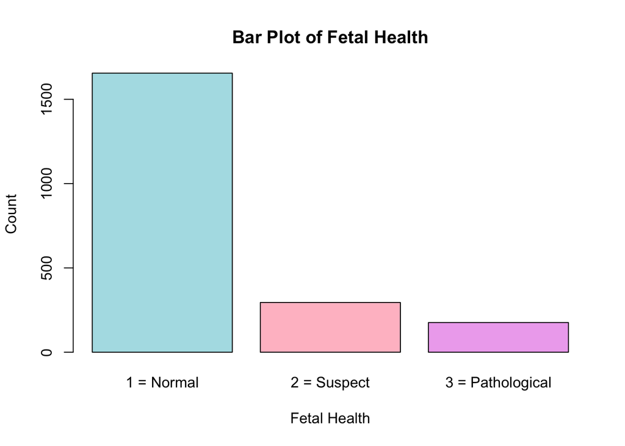

```r
barplot(table(fetal_df$fetal_health), col = c("powderblue", "pink", "plum2"),xlab = "Fetal Health", ylab = "Count", names.arg = c("1 = Normal", "2 = Suspect", "3 = Pathological"), main = "Bar Plot of Fetal Health")
```

### For Modelling Phase; create training and test sets

```r
## Create train and test sets; to be used later for modelling
set.seed(7)
sample_size = round(nrow(fetal_df2)*.80)
index <- sample(seq_len(nrow(fetal_df2)), size = sample_size)

fetal_train <- fetal_df2[index, ]
fetal_test <- fetal_df2[-index, ]


fetal_train_dim <- dim(fetal_train)
cat('Number of Rows in Student Training Dataset: ', fetal_train_dim[1])
```

```
## Number of Rows in Student Training Dataset:  1642
```

```r
cat('Number of Variables in Student Training Dataset: ', fetal_train_dim[2])
```

```
## Number of Variables in Student Training Dataset:  9
```

```r
#looking at dimensions of testing file
fetal_test_dim <- dim(fetal_test)
cat('Number of Rows in Student Testing Dataset: ', fetal_test_dim[1])
```

```
## Number of Rows in Student Testing Dataset:  411
```

```r
cat('Number of Variables in Student Testing Dataset: ', fetal_test_dim[2])
```

```
## Number of Variables in Student Testing Dataset:  9
```

```r
#looking at fetal health data
t1 <- table(fetal_train$fetal_health)
rownames(t1) <- c("1 = Normal", "2 = Suspect", " 3 = Pathalogical")
t1
```

```
##
##        1 = Normal       2 = Suspect  3 = Pathalogical
##              1305               245                92
```

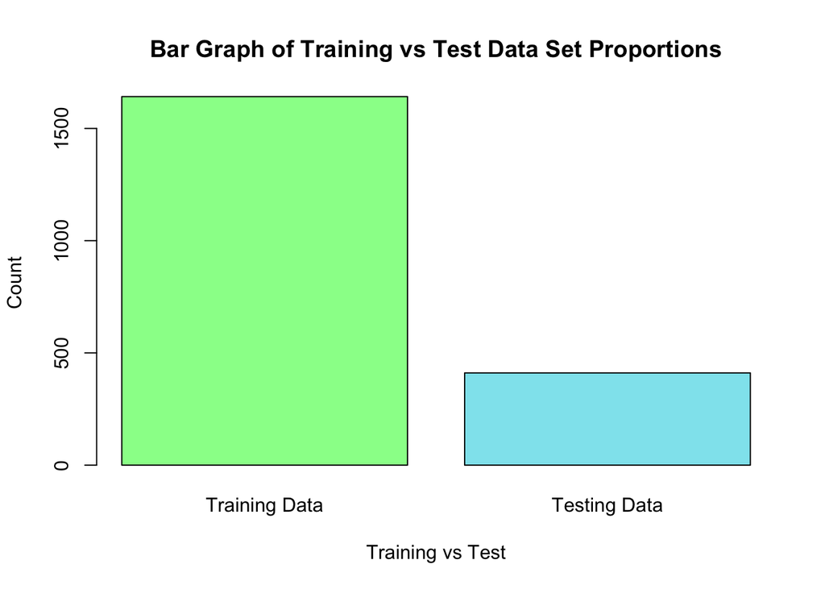

```r
#bar graph to see training and testing dimensions
fetal_train_test_prop <- c(fetal_train_dim[1], fetal_test_dim[1])

barplot(fetal_train_test_prop, col = c("palegreen", "cadetblue2"), main = "Bar Graph of Training vs Test Data Set Proportions", xlab = "Training vs Test", ylab = "Count", names.arg = c("Training Data", "Testing Data"), cex.names = 1)
```

#### Rebalancing the training set so that p(3) = .15

As mentioned earlier, most records in the dataset have fetal_health = 1. fetal_health = 3 had the lowest occurrence; which has been rebalanced to have a sample size closer to fetal_health = 2. The records are not perfectly balanced, but this new split ensures better sampling across the three classes.

```r
table(fetal_train$fetal_health)
```

```
##
##    1    2    3
## 1305  245   92
```

```r
#We can see that p(3) is currently .056 so let's increase it to .15
to.resample1 <- which(fetal_train$fetal_health == "3")
our.resample1 <- sample(x = to.resample1, size = 182, replace = TRUE)
our.resample1 <- fetal_train[our.resample1, ]
train_fetal_rebal <- rbind(fetal_train, our.resample1)
table(train_fetal_rebal$fetal_health)
```

```
##
##    1    2    3
## 1305  245  274
```

```r
#chi square test for homogeneity of proportions
#first making a table of training count and testing count for each target var
table5.2 <- as.table(rbind(c(1390, 237, 278), c(329, 56, 26)))
dimnames(table5.2) <- list(Data.set = c("Training Set", "Test Set"), Status = c("1", "2", "3"))
Xsq_data <- chisq.test(table5.2)
#test statistic
Xsq_data$statistic
```

```
## X-squared
##  20.26222
```

```r
#p-value
Xsq_data$p.value
```

```
## [1] 0.00003982115
```

```r
#expected counts
Xsq_data$expected
```

```
##               Status
## Data.set               1         2         3
##   Training Set 1413.9443 241.00389 250.05181
##   Test Set      305.0557  51.99611  53.94819
```

```r
write.csv(fetal_test,"/Users/bikramgill/Documents/GitHub/ADS502/fetal_test.csv")
```

## Classification Models

Now that our features have been selected, data has been cleaned and train/test data has been prepared, we will evaluate the performance of various classification models on this dataset. The goal is to determine whether underlying data can be used to determine fetal health accurately, and if so, which model provides the best results.

This will be further explored in our overall paper.

### Evaluation function

This function has been defined to compute evaluation metrics based on contingency tables. It will be used by our classification models further below.

```r
## Define function for later use.
summaryStats <- function(cm) {
  #convert confusion matrix to matrix
  cm <- as.matrix(cm)
  #number of instances
  n = sum(cm)
  #numbers of classes
  nc = nrow(cm)
  #correctly classified instances in a class
  diag = diag(cm)
  #numbers of instances in a class
  rowsums = apply(cm, 1, sum)
  #number of predictions in a class
  colsums = apply(cm, 2, sum)
  accuracy = sum(diag)/n
  error_rate = 1 - accuracy
  # precision = diag/colsums
  # recall = diag/rowsums
  precision = diag/rowsums
  recall = diag/colsums
  f1 = 2* precision*recall / (precision + recall)
  f2 = 5*(precision*recall) / ((4*precision) + recall)
  f0.5 = 1.25*(precision*recall) / ((0.25*precision) + recall)
  fetal.health <- c(1,2,3)
  theRest <- data.frame(fetal.health,precision, recall, f1, f2, f0.5)
  theRest <- theRest %>% kbl(caption = sprintf("Accuracy: %f \\\\ Error Rate: %f", accuracy, error_rate) ) %>%  kable_classic(full_width = F, html_font = "Cambria")
  return(theRest)

}
```

### Logistic Regression

```r
#train regression model
logreg02 <- multinom(fetal_health ~ prolongued_decelerations + abnormal_short_term_variability + percentage_of_time_with_abnormal_long_term_variability + accelerations + histogram_mode + mean_value_of_long_term_variability + histogram_variance + uterine_contractions, data = train_fetal_rebal)
#prediction on test data
lpred <- predict(logreg02, fetal_test, type = 'class')
table(fetal_test$fetal_health, lpred)
```

```
##    lpred
##       1   2   3
##   1 319  10   4
##   2  16  23   9
##   3   4   6  20
```

```r
#evalutation metrics
logreg_cm <- confusionMatrix(lpred, factor(fetal_test$fetal_health))
summaryStats(logreg_cm)
```

Accuracy: 0.880779 \ Error Rate: 0.119221

| fetal.health | precision | recall | f1 | f2 | f0.5 |
| --- | --- | --- | --- | --- | --- |
| 1 | 0.9410029 | 0.9579580 | 0.9494048 | 0.9545183 | 0.9443458 |
| 2 | 0.5897436 | 0.4791667 | 0.5287356 | 0.4978355 | 0.5637255 |
| 3 | 0.6060606 | 0.6666667 | 0.6349206 | 0.6535948 | 0.6172840 |

### K-NN

```r
#normalize data
data_norm <- function(x) {((x - min(x)) / (max(x) - min(x)))}

#normalize train and test data
fetal_train_norm <- as.data.frame(lapply(fetal_train[ , c(1:8)], data_norm))
fetal_test_norm <- as.data.frame(lapply(fetal_test[ , c(1:8)], data_norm))

#getting our target variable
fetal_train_labels <- fetal_train[1:fetal_train_dim[1], 9]
fetal_test_labels <- fetal_test[1:fetal_test_dim[1], 9]


#k decided based on the squareroot of data points
#training dataset has 1642 variables. Therefore k is ~40

fetal_pred <- knn(fetal_train_norm, fetal_test_norm, fetal_train_labels, k = 40)
table_KNN <- table(fetal_pred, fetal_test_labels)
table_KNN <- addmargins(A = table_KNN, FUN = list(Total = sum), quiet = TRUE)
table_KNN
```

```
##           fetal_test_labels
## fetal_pred   1   2   3 Total
##      1     326  16   7   349
##      2       6  27   6    39
##      3       1   5  17    23
##      Total 333  48  30   411
```

```r
#evaluation metrics
KNN_cm <-confusionMatrix(fetal_pred, factor(fetal_test$fetal_health))
KNN_cm
```

```
## Confusion Matrix and Statistics
##
##           Reference
## Prediction   1   2   3
##          1 326  16   7
##          2   6  27   6
##          3   1   5  17
##
## Overall Statistics
##
##                Accuracy : 0.9002
##                  95% CI : (0.8671, 0.9275)
##     No Information Rate : 0.8102
##     P-Value [Acc > NIR] : 0.0000004042
##
##                   Kappa : 0.6639
##
##  Mcnemar's Test P-Value : 0.02753
##
## Statistics by Class:
##
##                      Class: 1 Class: 2 Class: 3
## Sensitivity            0.9790  0.56250  0.56667
## Specificity            0.7051  0.96694  0.98425
## Pos Pred Value         0.9341  0.69231  0.73913
## Neg Pred Value         0.8871  0.94355  0.96649
## Prevalence             0.8102  0.11679  0.07299
## Detection Rate         0.7932  0.06569  0.04136
## Detection Prevalence   0.8491  0.09489  0.05596
## Balanced Accuracy      0.8421  0.76472  0.77546
```

```r
summaryStats(KNN_cm)
```

Accuracy: 0.900243 \ Error Rate: 0.099757

| fetal.health | precision | recall | f1 | f2 | f0.5 |
| --- | --- | --- | --- | --- | --- |
| 1 | 0.9340974 | 0.9789790 | 0.9560117 | 0.9696609 | 0.9427415 |
| 2 | 0.6923077 | 0.5625000 | 0.6206897 | 0.5844156 | 0.6617647 |
| 3 | 0.7391304 | 0.5666667 | 0.6415094 | 0.5944056 | 0.6967213 |

### Decision Tree: CART

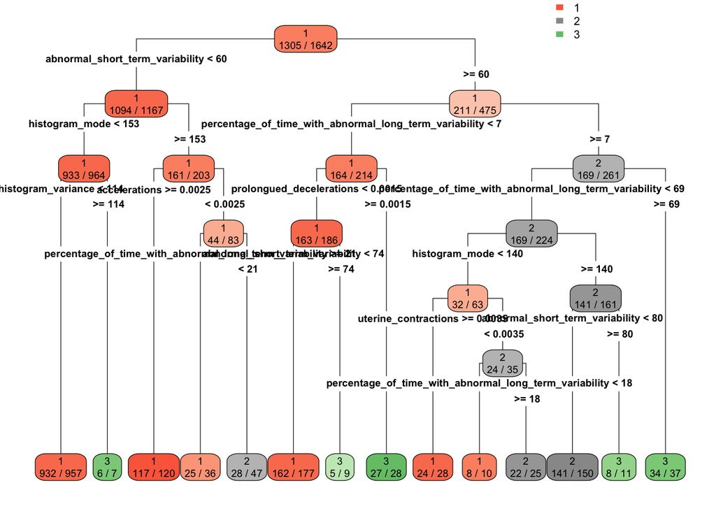

```r
#normalize data
fetal_train$fetal_health <- factor(fetal_train$fetal_health)
fetal_test$fetal_health <- factor(fetal_test$fetal_health)

#train CART model
cart01_fetal_train <- rpart(formula = fetal_health ~ prolongued_decelerations + abnormal_short_term_variability + percentage_of_time_with_abnormal_long_term_variability + accelerations + histogram_mode + mean_value_of_long_term_variability + histogram_variance +uterine_contractions, data = fetal_train)

rpart.plot(cart01_fetal_train, type = 4, extra = 2, cex = 0.6)
```

```r
#prediction on test data
X_fetal_test_cart <- data.frame(prolongued_decelerations = fetal_test$prolongued_decelerations, abnormal_short_term_variability = fetal_test$abnormal_short_term_variability,percentage_of_time_with_abnormal_long_term_variability = fetal_test$percentage_of_time_with_abnormal_long_term_variability, accelerations = fetal_test$accelerations, histogram_mode = fetal_test$histogram_mode, mean_value_of_long_term_variability = fetal_test$mean_value_of_long_term_variability, histogram_variance = fetal_test$histogram_variance, uterine_contractions = fetal_test$uterine_contractions, fetal_health =fetal_test$fetal_health )

fetal_predCart <- predict(object = cart01_fetal_train, newdata = X_fetal_test_cart, type = "class")

#evaluation metrics
table_CART <- table(fetal_test$fetal_health, fetal_predCart)
table_CART <- addmargins(A = table_CART, FUN = list(Total=sum), quiet = TRUE)
table_CART
```

```
##        fetal_predCart
##           1   2   3 Total
##   1     322   6   5   333
##   2       9  38   1    48
##   3       7   2  21    30
##   Total 338  46  27   411
```

```r
CART_cm <- confusionMatrix(fetal_predCart, fetal_test$fetal_health)
CART_cm
```

```
## Confusion Matrix and Statistics
##
##           Reference
## Prediction   1   2   3
##          1 322   9   7
##          2   6  38   2
##          3   5   1  21
##
## Overall Statistics
##
##                Accuracy : 0.927
##                  95% CI : (0.8974, 0.9502)
##     No Information Rate : 0.8102
##     P-Value [Acc > NIR] : 0.00000000001657
##
##                   Kappa : 0.7689
##
##  Mcnemar's Test P-Value : 0.7371
##
## Statistics by Class:
##
##                      Class: 1 Class: 2 Class: 3
## Sensitivity            0.9670  0.79167  0.70000
## Specificity            0.7949  0.97796  0.98425
## Pos Pred Value         0.9527  0.82609  0.77778
## Neg Pred Value         0.8493  0.97260  0.97656
## Prevalence             0.8102  0.11679  0.07299
## Detection Rate         0.7835  0.09246  0.05109
## Detection Prevalence   0.8224  0.11192  0.06569
## Balanced Accuracy      0.8809  0.88481  0.84213
```

```r
summaryStats(CART_cm)
```

Accuracy: 0.927007 \ Error Rate: 0.072993

| fetal.health | precision | recall | f1 | f2 | f0.5 |
| --- | --- | --- | --- | --- | --- |
| 1 | 0.9526627 | 0.9669670 | 0.9597615 | 0.9640719 | 0.9554896 |
| 2 | 0.8260870 | 0.7916667 | 0.8085106 | 0.7983193 | 0.8189655 |
| 3 | 0.7777778 | 0.7000000 | 0.7368421 | 0.7142857 | 0.7608696 |

### Decision Tree: C5

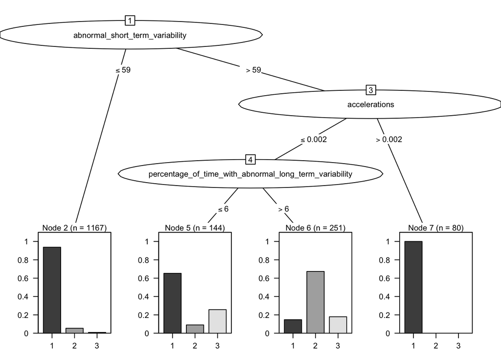

```r
#train C5 model
C5_fetal <- C5.0(formula = fetal_health ~ prolongued_decelerations + abnormal_short_term_variability + percentage_of_time_with_abnormal_long_term_variability + accelerations + histogram_mode + mean_value_of_long_term_variability + histogram_variance +uterine_contractions, data = fetal_train, control = C5.0Control(minCases = 75))

plot(C5_fetal, gp = gpar(fontsize = 8))
```

```r
#prediction on test data
fetal_pred_C5 <- predict(object = C5_fetal, newdata = X_fetal_test_cart)

#evaluation metrics
table_C5 <- table(fetal_test$fetal_health, fetal_pred_C5 )
table_C5 <- addmargins(A = table_C5, FUN = list(Total=sum), quiet = TRUE)
table_C5
```

```
##        fetal_pred_C5
##           1   2   3 Total
##   1     325   8   0   333
##   2      18  30   0    48
##   3      16  14   0    30
##   Total 359  52   0   411
```

```r
C5_cm <- confusionMatrix(fetal_pred_C5, fetal_test$fetal_health)
C5_cm
```

```
## Confusion Matrix and Statistics
##
##           Reference
## Prediction   1   2   3
##          1 325  18  16
##          2   8  30  14
##          3   0   0   0
##
## Overall Statistics
##
##                Accuracy : 0.8637
##                  95% CI : (0.8267, 0.8954)
##     No Information Rate : 0.8102
##     P-Value [Acc > NIR] : 0.002554
##
##                   Kappa : 0.509
##
##  Mcnemar's Test P-Value : 0.0000002135
##
## Statistics by Class:
##
##                      Class: 1 Class: 2 Class: 3
## Sensitivity            0.9760  0.62500  0.00000
## Specificity            0.5641  0.93939  1.00000
## Pos Pred Value         0.9053  0.57692      NaN
## Neg Pred Value         0.8462  0.94986  0.92701
## Prevalence             0.8102  0.11679  0.07299
## Detection Rate         0.7908  0.07299  0.00000
## Detection Prevalence   0.8735  0.12652  0.00000
## Balanced Accuracy      0.7700  0.78220  0.50000
```

```r
summaryStats(C5_cm)
```

Accuracy: 0.863747 \ Error Rate: 0.136253

| fetal.health | precision | recall | f1 | f2 | f0.5 |
| --- | --- | --- | --- | --- | --- |
| 1 | 0.9052925 | 0.975976 | 0.9393064 | 0.9609698 | 0.9185981 |
| 2 | 0.5769231 | 0.625000 | 0.6000000 | 0.6147541 | 0.5859375 |
| 3 | NaN | 0.000000 | NaN | NaN | NaN |

### Random Forest

```r
#train random forest model
random_Fetal <- randomForest(formula = fetal_health ~ prolongued_decelerations + abnormal_short_term_variability + percentage_of_time_with_abnormal_long_term_variability + accelerations + histogram_mode + mean_value_of_long_term_variability + histogram_variance +uterine_contractions, data = fetal_train, ntree = 100, type = "classification")

#prediction on test data
fetal_random_pred <- predict(object = random_Fetal, X_fetal_test_cart)

#evaluation metrics
table_RF <- table(fetal_test$fetal_health, fetal_random_pred)
table_RF <- addmargins(A = table_RF, FUN = list(Total=sum), quiet = TRUE)
table_RF
```

```
##        fetal_random_pred
##           1   2   3 Total
##   1     330   2   1   333
##   2      11  37   0    48
##   3       3   5  22    30
##   Total 344  44  23   411
```

```r
randforest_cm <- confusionMatrix(fetal_random_pred, fetal_test$fetal_health)
randforest_cm
```

```
## Confusion Matrix and Statistics
##
##           Reference
## Prediction   1   2   3
##          1 330  11   3
##          2   2  37   5
##          3   1   0  22
##
## Overall Statistics
##
##                Accuracy : 0.9465
##                  95% CI : (0.9201, 0.9662)
##     No Information Rate : 0.8102
##     P-Value [Acc > NIR] : 0.0000000000000007778
##
##                   Kappa : 0.8247
##
##  Mcnemar's Test P-Value : 0.006633
##
## Statistics by Class:
##
##                      Class: 1 Class: 2 Class: 3
## Sensitivity            0.9910  0.77083  0.73333
## Specificity            0.8205  0.98072  0.99738
## Pos Pred Value         0.9593  0.84091  0.95652
## Neg Pred Value         0.9552  0.97003  0.97938
## Prevalence             0.8102  0.11679  0.07299
## Detection Rate         0.8029  0.09002  0.05353
## Detection Prevalence   0.8370  0.10706  0.05596
## Balanced Accuracy      0.9058  0.87577  0.86535
```

```r
summaryStats(randforest_cm)
```

Accuracy: 0.946472 \ Error Rate: 0.053528

| fetal.health | precision | recall | f1 | f2 | f0.5 |
| --- | --- | --- | --- | --- | --- |
| 1 | 0.9593023 | 0.9909910 | 0.9748892 | 0.9844869 | 0.9654769 |
| 2 | 0.8409091 | 0.7708333 | 0.8043478 | 0.7838983 | 0.8258929 |
| 3 | 0.9565217 | 0.7333333 | 0.8301887 | 0.7692308 | 0.9016393 |

### Naive Bayes

```r
#normalize data
cols = c('prolongued_decelerations', 'abnormal_short_term_variability', 'percentage_of_time_with_abnormal_long_term_variability', 'accelerations', 'histogram_mode', 'mean_value_of_long_term_variability', 'histogram_variance', 'uterine_contractions','fetal_health')
train_fetal_rebal[, cols] <- lapply(train_fetal_rebal[, cols], as.factor)

#train NB model
nb01 <- naiveBayes(formula = fetal_health ~ prolongued_decelerations + abnormal_short_term_variability + percentage_of_time_with_abnormal_long_term_variability + accelerations + histogram_mode + mean_value_of_long_term_variability + histogram_variance + uterine_contractions, data = train_fetal_rebal)

#prediction on test data
fetal_test[, cols] <- lapply(fetal_test[, cols], as.factor)
ypred <- predict(object = nb01, newdata = fetal_test)
```

```r
#evaluation metrics
t.preds <- table(fetal_test$fetal_health, ypred)
rownames(t.preds) <- c("Actual: 1", "Actual: 2", "Actual: 3")
colnames(t.preds) <- c("Predicted: 1", "Predicted: 2", "Predicted: 3   ")
addmargins(A = t.preds, FUN = list(Total = sum), quiet = TRUE)
```

```
##            ypred
##             Predicted: 1 Predicted: 2 Predicted: 3    Total
##   Actual: 1          307           19               7   333
##   Actual: 2           11           35               2    48
##   Actual: 3            2            7              21    30
##   Total              320           61              30   411
```

```r
fetal_test[, cols] <- lapply(fetal_test[, cols], as.factor)
predictions <- predict(nb01, fetal_test)

nb_cm <- confusionMatrix(predictions, fetal_test[, 'fetal_health'], positive='yes')
nb_cm
```

```
## Confusion Matrix and Statistics
##
##           Reference
## Prediction   1   2   3
##          1 307  11   2
##          2  19  35   7
##          3   7   2  21
##
## Overall Statistics
##
##                Accuracy : 0.8832
##                  95% CI : (0.8482, 0.9126)
##     No Information Rate : 0.8102
##     P-Value [Acc > NIR] : 0.00004501
##
##                   Kappa : 0.663
##
##  Mcnemar's Test P-Value : 0.0529
##
## Statistics by Class:
##
##                      Class: 1 Class: 2 Class: 3
## Sensitivity            0.9219  0.72917  0.70000
## Specificity            0.8333  0.92837  0.97638
## Pos Pred Value         0.9594  0.57377  0.70000
## Neg Pred Value         0.7143  0.96286  0.97638
## Prevalence             0.8102  0.11679  0.07299
## Detection Rate         0.7470  0.08516  0.05109
## Detection Prevalence   0.7786  0.14842  0.07299
## Balanced Accuracy      0.8776  0.82877  0.83819
```

```r
summaryStats(nb_cm)
```

Accuracy: 0.883212 \ Error Rate: 0.116788

| fetal.health | precision | recall | f1 | f2 | f0.5 |
| --- | --- | --- | --- | --- | --- |
| 1 | 0.9593750 | 0.9219219 | 0.9402757 | 0.9291768 | 0.9516429 |
| 2 | 0.5737705 | 0.7291667 | 0.6422018 | 0.6916996 | 0.5993151 |
| 3 | 0.7000000 | 0.7000000 | 0.7000000 | 0.7000000 | 0.7000000 |

## Code Appendix

### Code Appendix 1: Boxplots and Histograms for each Feature

#### accelerations

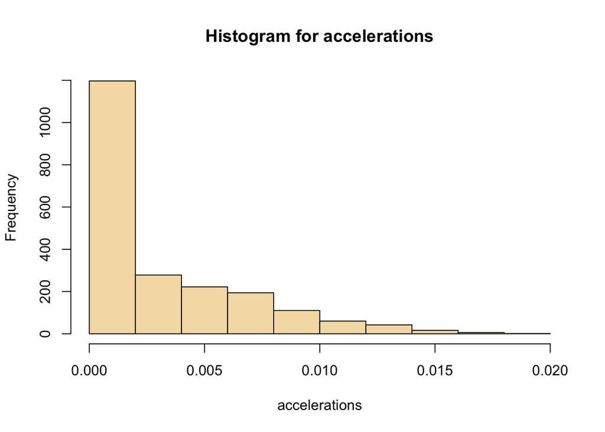

```r
hist(fetal_df$accelerations,
     main="Histogram for accelerations",
     xlab="accelerations",
     border="black",
     col="wheat")
```

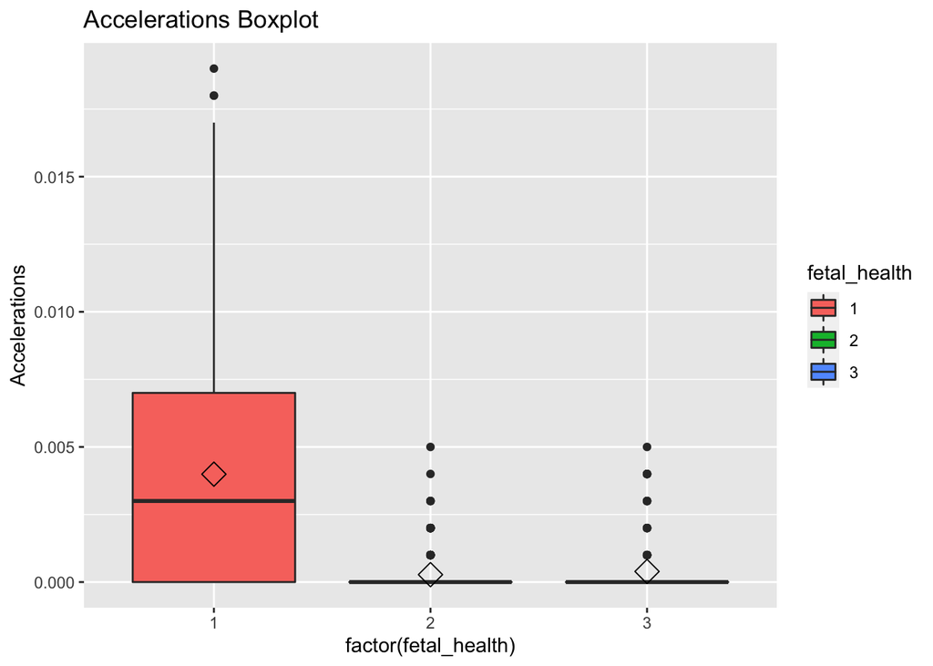

```r
temp_fetal_df <- fetal_df
temp_fetal_df$fetal_health <- factor(temp_fetal_df$fetal_health)

accelerations_boxplot <- ggplot(data = temp_fetal_df, aes(x = factor(fetal_health), y = accelerations))
accelerations_boxplot + geom_boxplot(aes(fill = fetal_health)) + ylab("Accelerations") + ggtitle("Accelerations Boxplot") + stat_summary(fun=mean, geom = "point", shape = 5, size = 4)
```

#### uterine_contractions

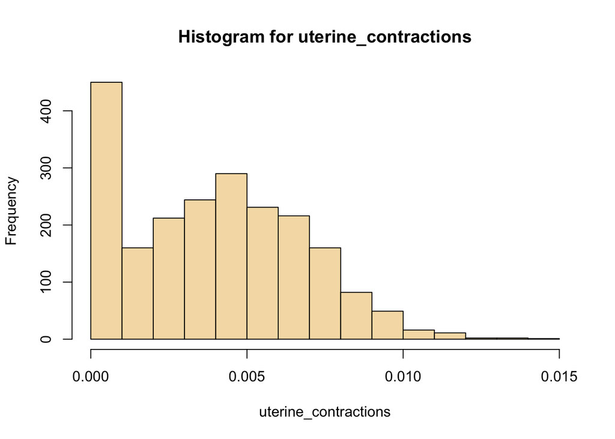

```r
hist(fetal_df$uterine_contractions,
     main="Histogram for uterine_contractions",
     xlab="uterine_contractions",
     border="black",
     col="wheat")
```

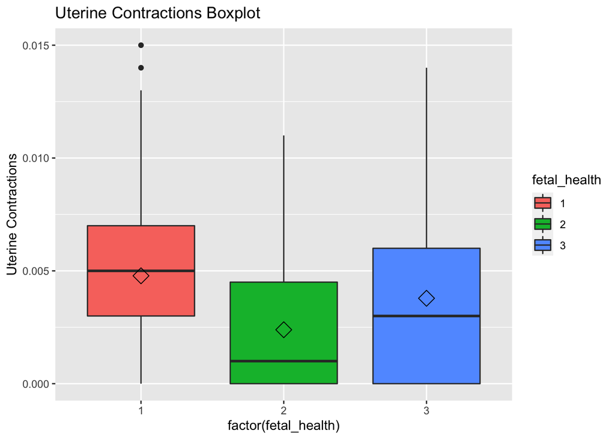

```r
temp_fetal_df <- fetal_df
temp_fetal_df$fetal_health <- factor(temp_fetal_df$fetal_health)

uterine_contractions_boxplot <- ggplot(data = temp_fetal_df, aes(x = factor(fetal_health), y = uterine_contractions))
uterine_contractions_boxplot + geom_boxplot(aes(fill = fetal_health)) + ylab("Uterine Contractions") + ggtitle("Uterine Contractions Boxplot") + stat_summary(fun=mean, geom = "point", shape = 5, size = 4)
```

#### prolongued_decelerations

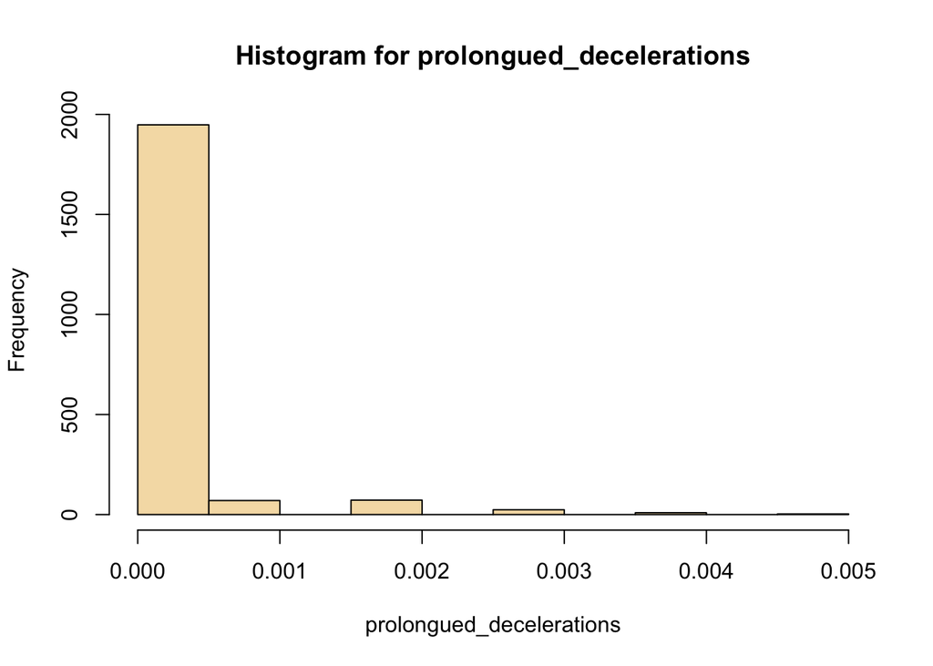

```r
hist(fetal_df$prolongued_decelerations,
     main="Histogram for prolongued_decelerations",
     xlab="prolongued_decelerations",
     border="black",
     col="wheat")
```

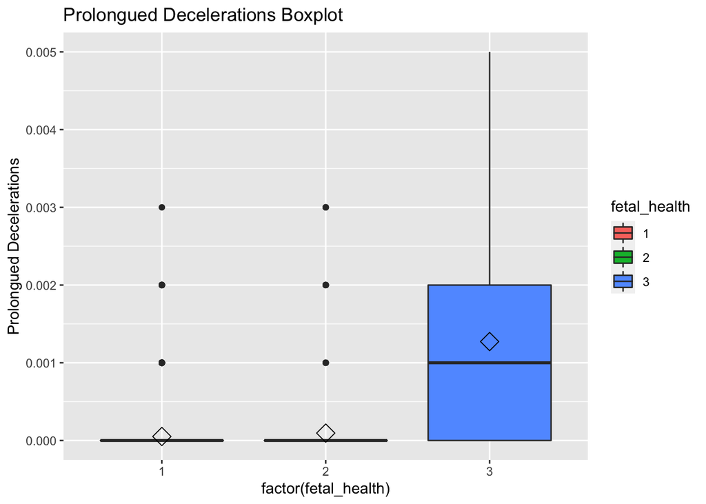

```r
temp_fetal_df <- fetal_df
temp_fetal_df$fetal_health <- factor(temp_fetal_df$fetal_health)

prolongued_decelerations_boxplot <- ggplot(data = temp_fetal_df, aes(x = factor(fetal_health), y = prolongued_decelerations))
prolongued_decelerations_boxplot + geom_boxplot(aes(fill = fetal_health)) + ylab("Prolongued Decelerations") + ggtitle("Prolongued Decelerations Boxplot") + stat_summary(fun=mean, geom = "point", shape = 5, size = 4)
```

#### abnormal_short_term_variability

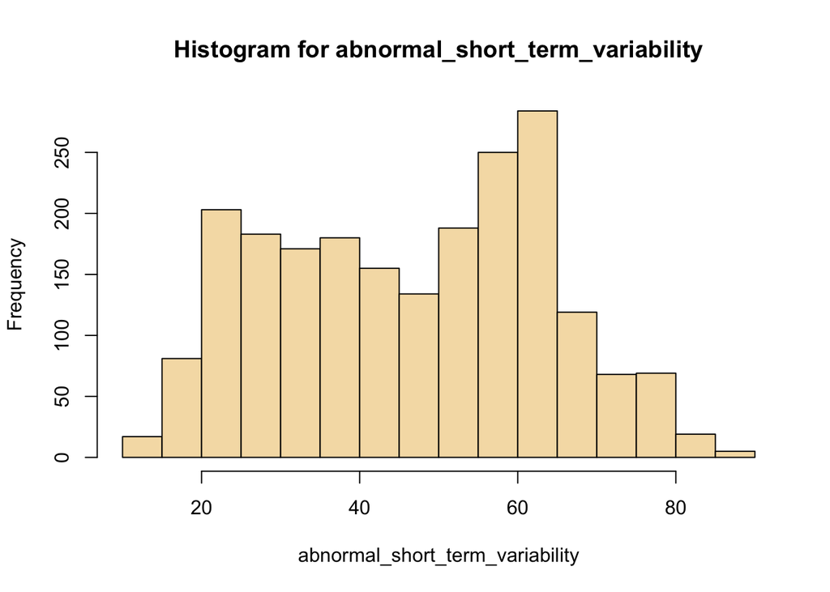

```r
hist(fetal_df$abnormal_short_term_variability,
     main="Histogram for abnormal_short_term_variability",
     xlab="abnormal_short_term_variability",
     border="black",
     col="wheat")
```

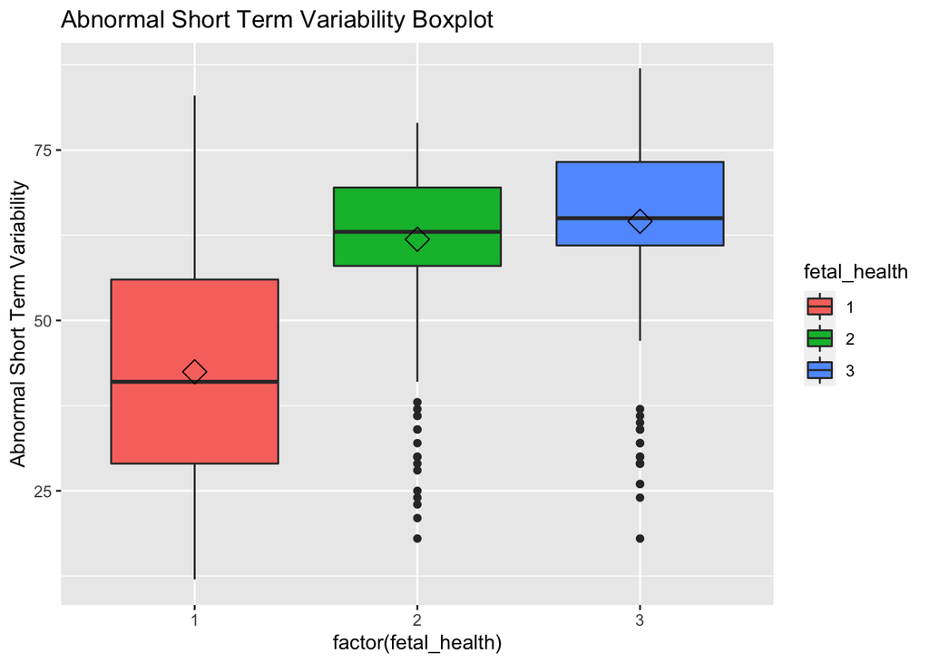

```r
temp_fetal_df <- fetal_df
temp_fetal_df$fetal_health <- factor(temp_fetal_df$fetal_health)

abnormal_short_term_variability_boxplot <- ggplot(data = temp_fetal_df, aes(x = factor(fetal_health), y = abnormal_short_term_variability))
abnormal_short_term_variability_boxplot + geom_boxplot(aes(fill = fetal_health)) + ylab("Abnormal Short Term Variability") + ggtitle("Abnormal Short Term Variability Boxplot") + stat_summary(fun=mean, geom = "point", shape = 5, size = 4)
```

#### percentage_of_time_with_abnormal_long_term_variability

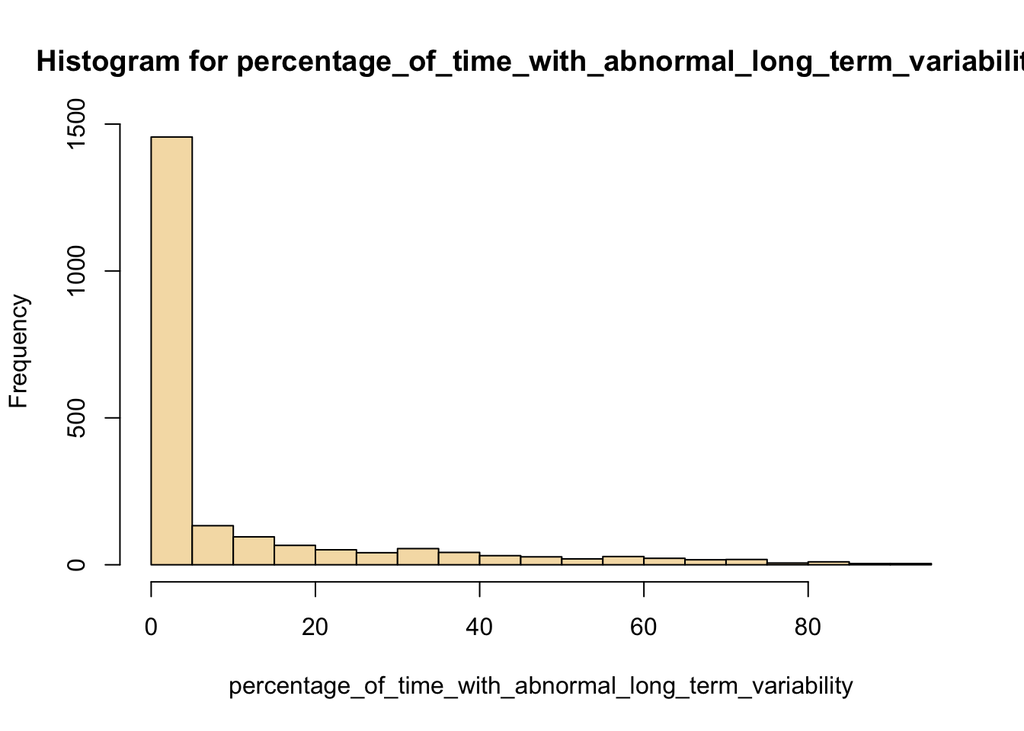

```r
hist(fetal_df$percentage_of_time_with_abnormal_long_term_variability,
     main="Histogram for percentage_of_time_with_abnormal_long_term_variability",
     xlab="percentage_of_time_with_abnormal_long_term_variability",
     border="black",
     col="wheat")
```

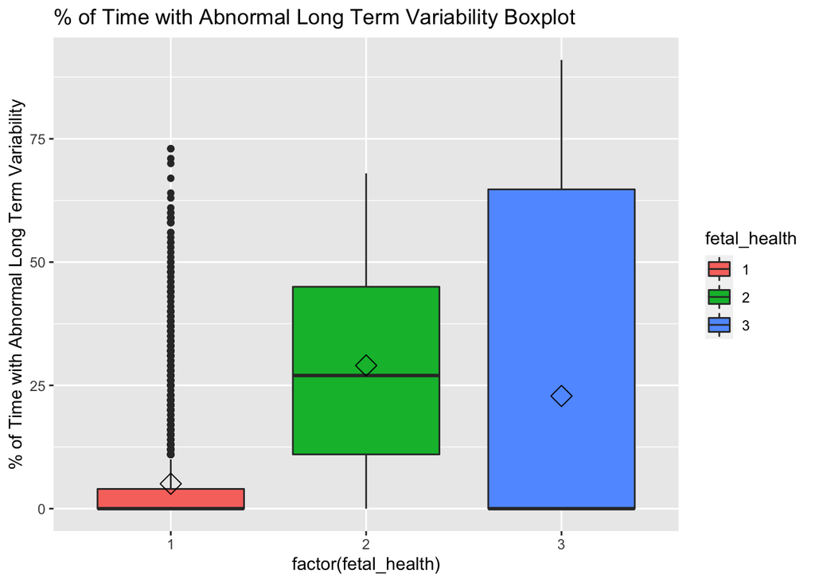

```r
temp_fetal_df <- fetal_df
temp_fetal_df$fetal_health <- factor(temp_fetal_df$fetal_health)

percentage_of_time_with_abnormal_long_term_variability_boxplot <- ggplot(data = temp_fetal_df, aes(x = factor(fetal_health), y = percentage_of_time_with_abnormal_long_term_variability))
percentage_of_time_with_abnormal_long_term_variability_boxplot + geom_boxplot(aes(fill = fetal_health)) + ylab("% of Time with Abnormal Long Term Variability") + ggtitle("% of Time with Abnormal Long Term Variability Boxplot") + stat_summary(fun=mean, geom = "point", shape = 5, size = 4)
```

#### mean_value_of_long_term_variability

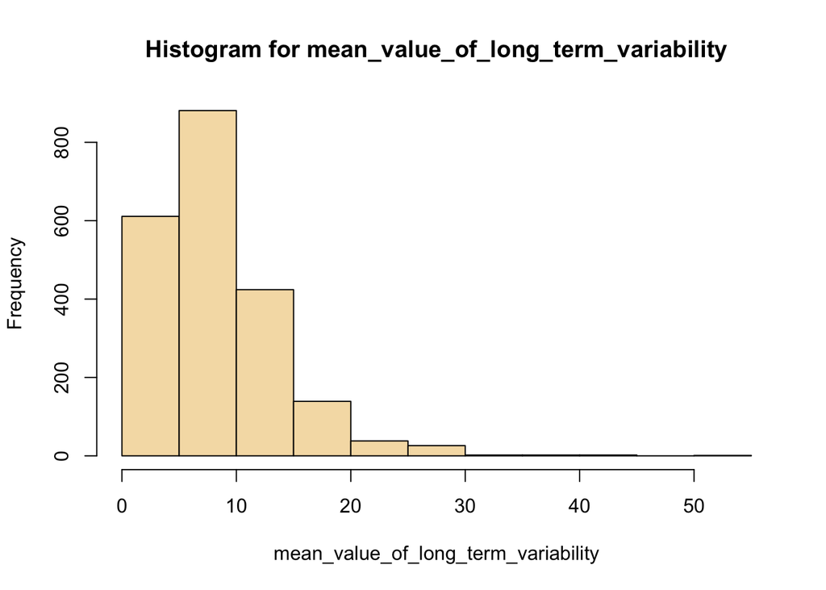

```r
hist(fetal_df$mean_value_of_long_term_variability,
     main="Histogram for mean_value_of_long_term_variability",
     xlab="mean_value_of_long_term_variability",
     border="black",
     col="wheat")
```

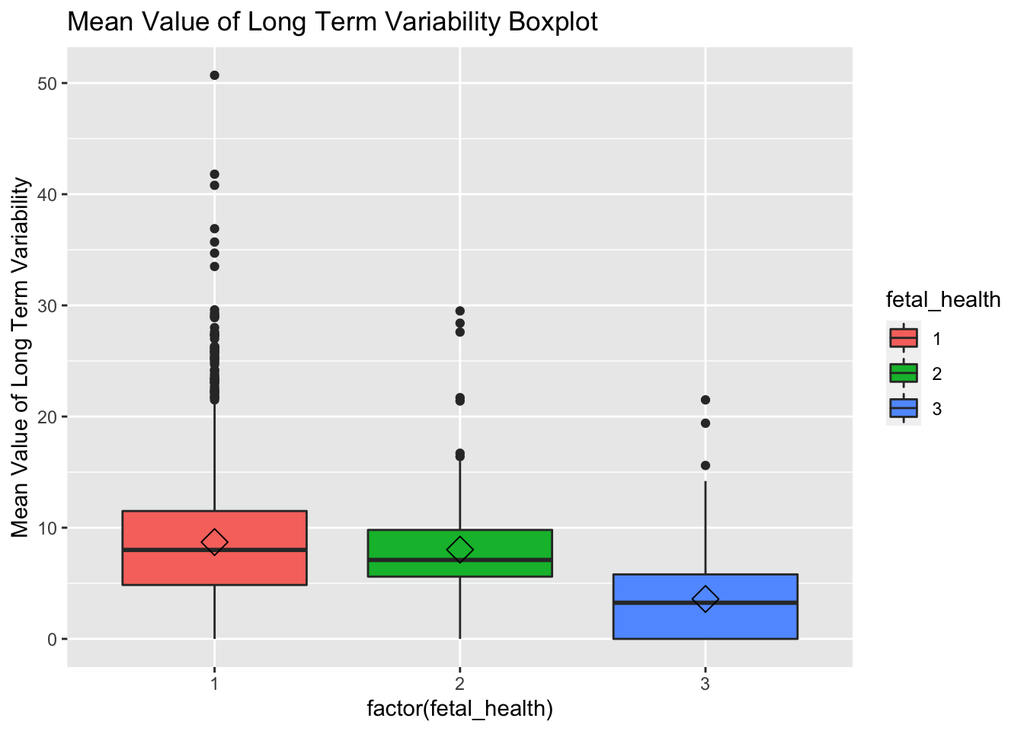

```r
temp_fetal_df <- fetal_df
temp_fetal_df$fetal_health <- factor(temp_fetal_df$fetal_health)

mean_value_of_long_term_variability_boxplot <- ggplot(data = temp_fetal_df, aes(x = factor(fetal_health), y = mean_value_of_long_term_variability))
mean_value_of_long_term_variability_boxplot + geom_boxplot(aes(fill = fetal_health)) + ylab("Mean Value of Long Term Variability") + ggtitle("Mean Value of Long Term Variability Boxplot") + stat_summary(fun=mean, geom = "point", shape = 5, size = 4)
```

#### histogram_mode

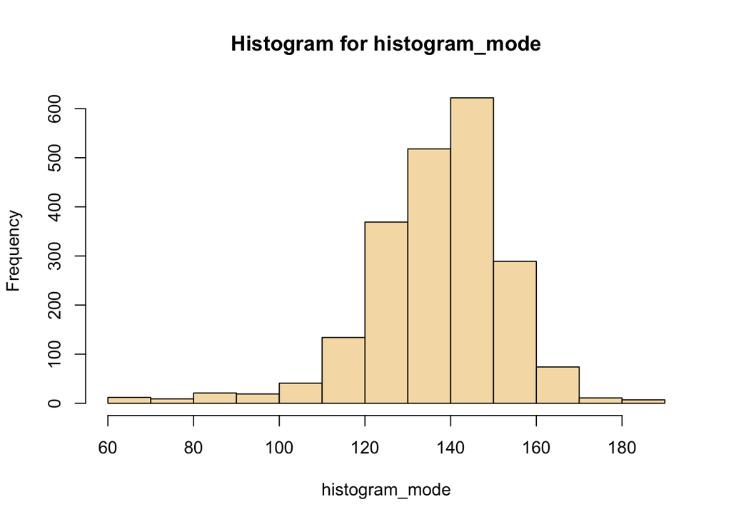

```r
hist(fetal_df$histogram_mode,
     main="Histogram for histogram_mode",
     xlab="histogram_mode",
     border="black",
     col="wheat")
```

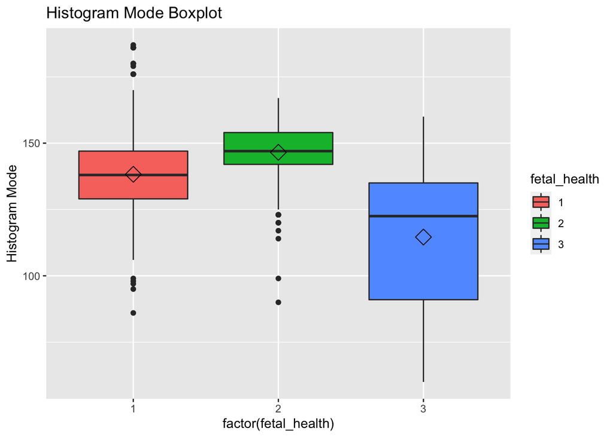

```r
temp_fetal_df <- fetal_df
temp_fetal_df$fetal_health <- factor(temp_fetal_df$fetal_health)

histogram_mode_boxplot <- ggplot(data = temp_fetal_df, aes(x = factor(fetal_health), y = histogram_mode))
histogram_mode_boxplot + geom_boxplot(aes(fill = fetal_health)) + ylab("Histogram Mode") + ggtitle("Histogram Mode Boxplot") + stat_summary(fun=mean, geom = "point", shape = 5, size = 4)
```

#### histogram_variance

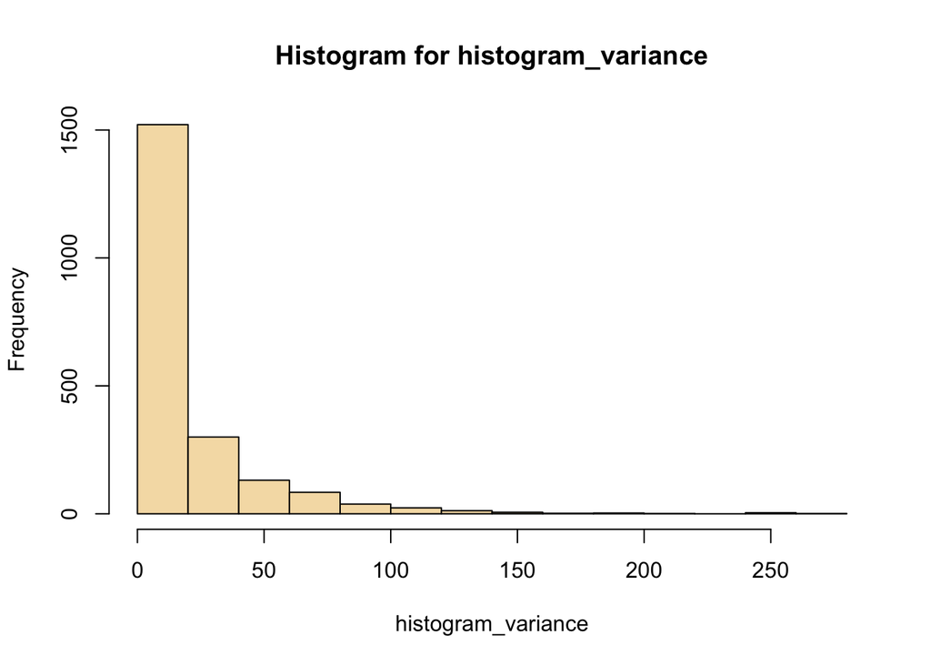

```r
hist(fetal_df$histogram_variance,
     main="Histogram for histogram_variance",
     xlab="histogram_variance",
     border="black",
     col="wheat")
```

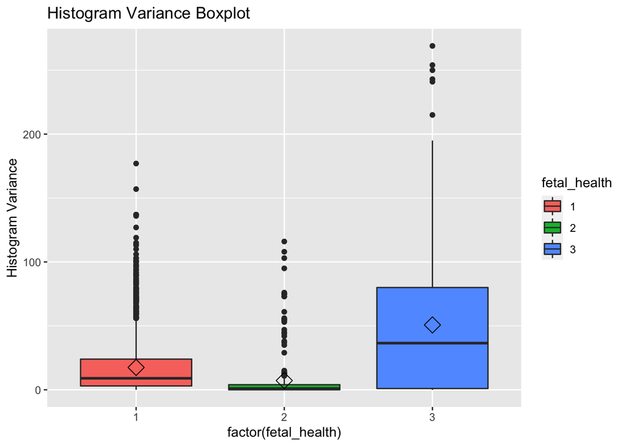

```r
temp_fetal_df <- fetal_df
temp_fetal_df$fetal_health <- factor(temp_fetal_df$fetal_health)

histogram_variance_boxplot <- ggplot(data = temp_fetal_df, aes(x = factor(fetal_health), y = histogram_variance))
histogram_variance_boxplot + geom_boxplot(aes(fill = fetal_health)) + ylab("Histogram Variance") + ggtitle("Histogram Variance Boxplot") + stat_summary(fun=mean, geom = "point", shape = 5, size = 4)
```